# Week 4-2 HW

Tyler Jackson

4/24/2019

# Week 4 Part 2 Setup

## Load Libraries

```r
library(rspatial)
library(tidyverse)
```

## Setup

```r
#read in data from rspatial
city <- sp_data("city")
crime <- sp_data("crime.rds")

#I don't think we need a wd path shortcut but just in case
mypath <- "/Users/tyler/Dropbox/_200CN/labs/week4-2/data/"
```

## Example Code

Map the City and Crime Data

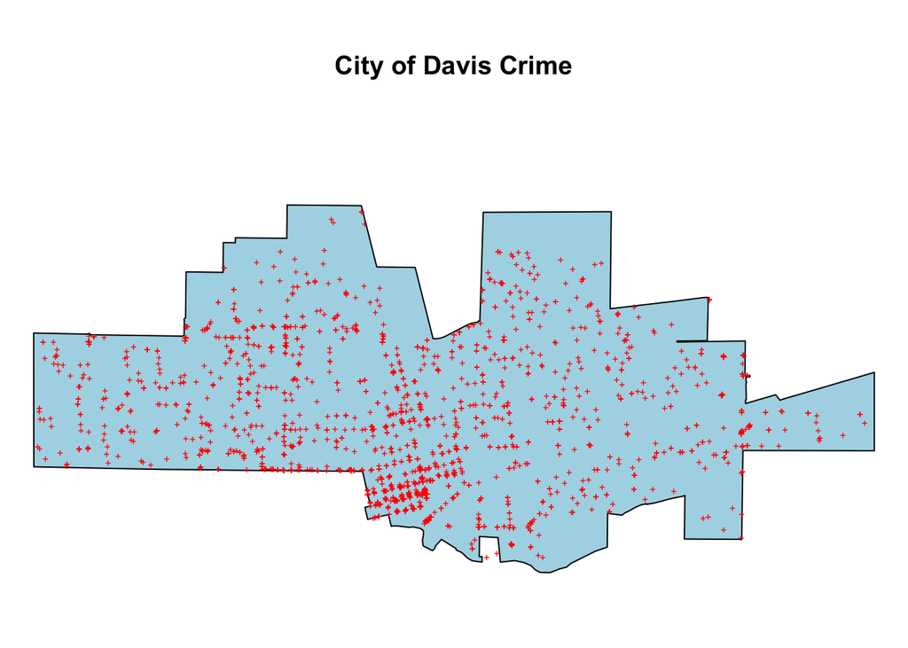

```r
#set the margins
par(mai=c(0,0,1,0))

#plot the polygons
plot(city, col='light blue', main = "City of Davis Crime")

#plot the points
points(crime, col='red', cex=.5, pch='+')
```

Get xy cooridinates and remove dupes

```r
#pull coords
xy <- coordinates(crime)

#isolate unique values
xy <- unique(xy)

#check it out
head(xy)
```

```
##      coords.x1 coords.x2
## [1,]   6628868   1963718
## [2,]   6632796   1964362
## [3,]   6636855   1964873
## [4,]   6626493   1964343
## [5,]   6639506   1966094
## [6,]   6640478   1961983
```

Get Density to Answer Question 1

```r
CityArea <- area(city)
dens <- nrow(xy) / CityArea
```

# Questions

## 1a Units

**What is the unit of ‘dens’?**

```r
crs(city)
```

```
## CRS arguments:
##  +proj=lcc +lat_1=38.33333333333334 +lat_2=39.83333333333334
## +lat_0=37.66666666666666 +lon_0=-122 +x_0=2000000
## +y_0=500000.0000000001 +datum=NAD83 +units=us-ft +no_defs
## +ellps=GRS80 +towgs84=0,0,0
```

## 1b Convert to Km

**What is the number of crimes per km<sup>2</sup>?**

```r
#transform into meters CRS
city.m <- spTransform(city, CRSobj = "+proj=lcc +lat_1=38.33333333333334 +lat_2=39.83333333333334 +lat_0=37.66666666666666 +lon_0=-122 +x_0=2000000 +y_0=500000.0000000001 +datum=NAD83 +units=km +no_defs +ellps=GRS80 +towgs84=0,0,0")
crime.m <- spTransform(crime, CRSobj = "+proj=lcc +lat_1=38.33333333333334 +lat_2=39.83333333333334 +lat_0=37.66666666666666 +lon_0=-122 +x_0=2000000 +y_0=500000.0000000001 +datum=NAD83 +units=km +no_defs +ellps=GRS80 +towgs84=0,0,0")
```

Plot to make sure it works ok?

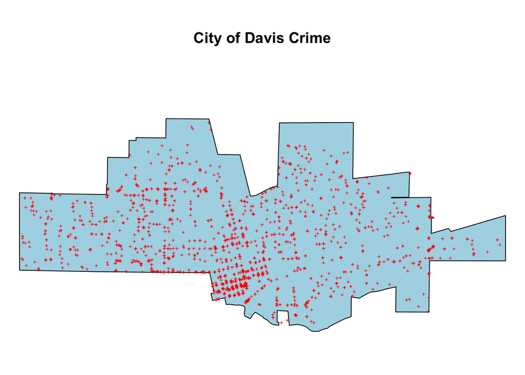

```r
#set the margins
par(mai=c(0,0,1,0))

#plot the polygons
plot(city.m, col='light blue', main = "City of Davis Crime")

#plot the points
points(crime.m, col='red', cex=.5, pch='+')
```

Get xy and isolate

```r
#pull coords
xy.m <- coordinates(crime.m)

#isolate unique values
xy.m <- unique(xy.m)

#check it out
head(xy.m)
```

```
##      coords.x1 coords.x2
## [1,]  2020.483  598.5424
## [2,]  2021.680  598.7387
## [3,]  2022.918  598.8944
## [4,]  2019.759  598.7328
## [5,]  2023.725  599.2667
## [6,]  2024.022  598.0137
```

Get denisty

```r
CityArea.m <- area(city.m)
dens.m <- nrow(xy.m) / CityArea.m
```

> The number of crimes per km<sup>2</sup> is 46.98.

Move on to Question 2. Some of the graphs from the example code are useful for answering the question so I’m including it here.

To compute quadrat counts (as on p.127-130), I first create quadrats (a RasterLayer). I get the extent for the raster from the city polygon, and then assign an an arbitrary resolution of 1000.

```r
#create a raster
r <- raster(city)

#set resolution, note: this is arbitrary
#note from robert: (In real life one should always try a range of resolutions, I think)
#he thinks?
res(r) <- 1000

#look good?
r
```

```
## class       : RasterLayer
## dimensions  : 15, 34, 510  (nrow, ncol, ncell)
## resolution  : 1000, 1000  (x, y)
## extent      : 6620591, 6654591, 1956519, 1971519  (xmin, xmax, ymin, ymax)
## coord. ref. : +proj=lcc +lat_1=38.33333333333334 +lat_2=39.83333333333334 +lat_0=37.66666666666666 +lon_0=-122 +x_0=2000000 +y_0=500000.0000000001 +datum=NAD83 +units=us-ft +no_defs +ellps=GRS80 +towgs84=0,0,0
```

To find the cells that are in the city, and for easy display, I create polygons from the RasterLayer.

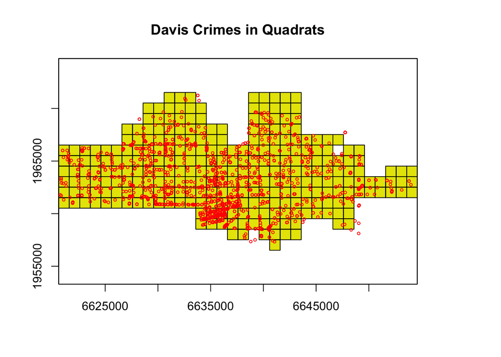

```r
#get cells in the city
r <- rasterize(city, r)

par(mar=c(5, 4, 4, 2) + 0.1)
plot(r, main = "Davis Crimes in Quadrats", legend = F)
#get polygons to see the squares
quads <- as(r, 'SpatialPolygons')

#plot them
plot(quads, add=TRUE)

#plot crime points
points(crime, col='red', cex=.5)
```

The number of events in each quadrat can be counted using the ‘rasterize’ function. That function can be used to summarize the number of points within each cell, but also to compute statistics based on the ‘marks’ (attributes). For example we could compute the number of different crime types) by changing the ‘fun’ argument to another function (see ?rasterize).

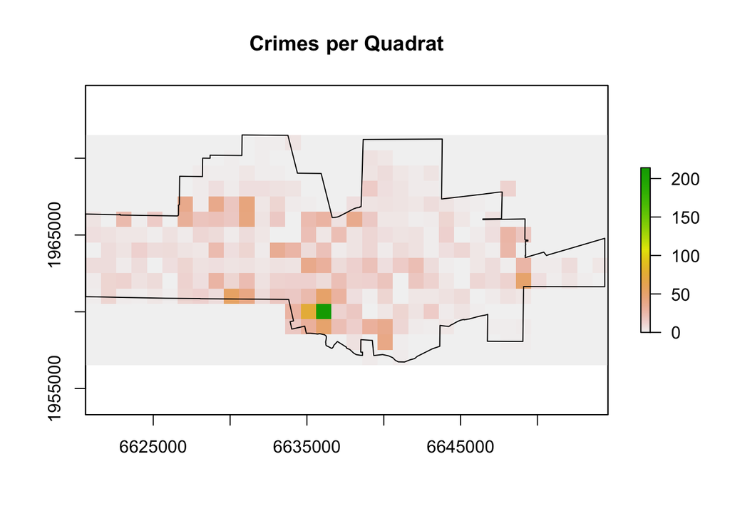

```r
#get counts in each quadrat
nc <- rasterize(coordinates(crime), r, fun='count', background=0)


plot(nc, main = "Crimes per Quadrat")
plot(city, add=TRUE)
```

`nc` has crime counts. As we only have data for the city, the areas outside of the city need to be excluded. We can do that with the mask function (see ?mask).

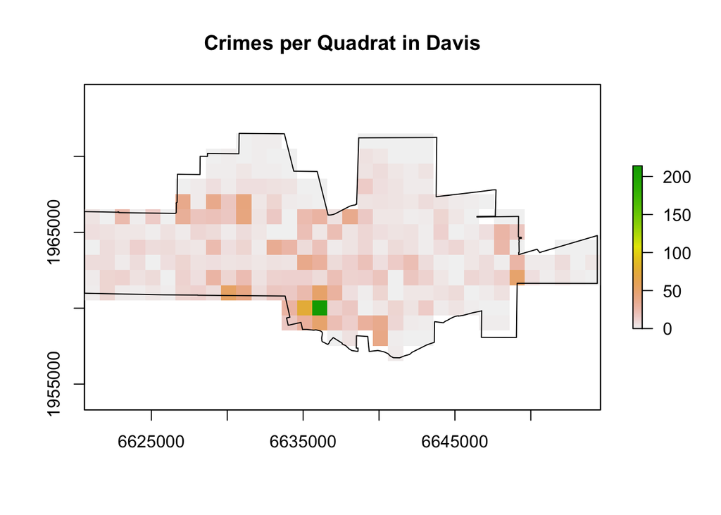

```r
#mask by the city to get rid of extra crime counts
ncrimes <- mask(nc, r)
plot(ncrimes, main = "Crimes per Quadrat in Davis")
plot(city, add=TRUE)
```

That looks better. Now let’s get the frequencies.

```r
#get frequencies
f <- freq(ncrimes, useNA='no')
head(f)
```

```
##      value count
## [1,]     0    48
## [2,]     1    29
## [3,]     2    24
## [4,]     3    22
## [5,]     4    19
## [6,]     5    16
```

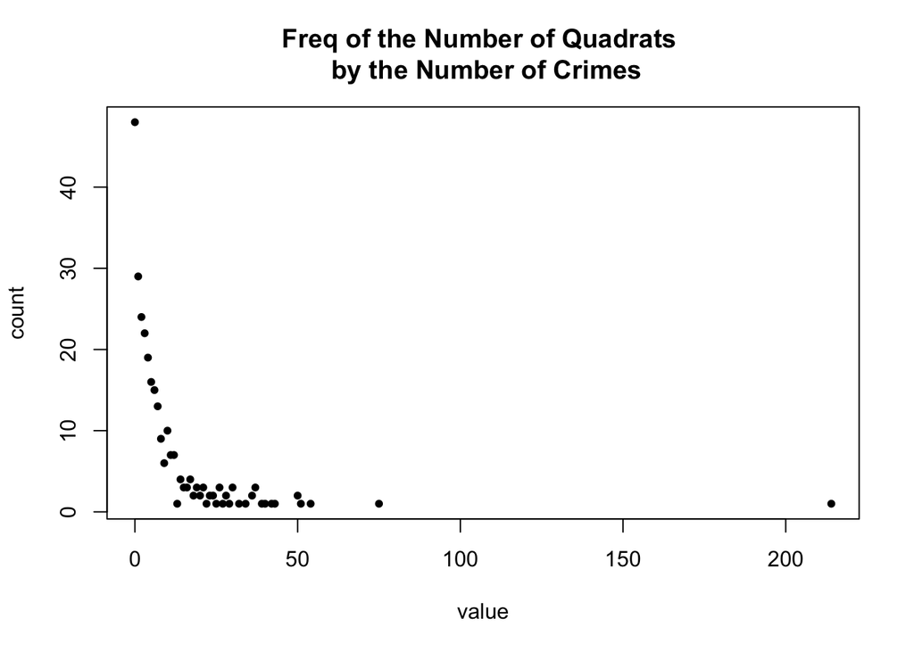

```r
plot(f, pch=20, main = "Freq of the Number of Quadrats \n by the Number of Crimes")
```

Compute the average number of cases per quadrat.

```r
# number of quadrats
quadrats <- sum(f[,2])
# number of cases
cases <- sum(f[,1] * f[,2])

#get the mean
mu <- cases / quadrats
mu
```

```
## [1] 9.261484
```

And create a table like Table 5.1 on page 130

```r
#create table for variance calculation
ff <- data.frame(f)

#K is events, X is quadrats
colnames(ff) <- c('K', 'X')

#difference between the mean and the observed
ff$Kmu <- ff$K - mu

#squared difference
ff$Kmu2 <- ff$Kmu^2

#squared diff times the number of quadrats
ff$XKmu2 <- ff$Kmu2 * ff$X
head(ff)
```

```
##   K  X       Kmu     Kmu2     XKmu2
## 1 0 48 -9.261484 85.77509 4117.2042
## 2 1 29 -8.261484 68.25212 1979.3115
## 3 2 24 -7.261484 52.72915 1265.4996
## 4 3 22 -6.261484 39.20618  862.5360
## 5 4 19 -5.261484 27.68321  525.9811
## 6 5 16 -4.261484 18.16025  290.5639
```

The observed variance s<sup>2</sup> is

```r
#get variance
s2 <- sum(ff$XKmu2) / (sum(ff$X)-1)
s2
```

```
## [1] 276.5555
```

And the VMR is

```r
#variance over mean
VMR <- s2 / mu
VMR
```

```
## [1] 29.86082
```

## 2 Decipher VMR

**What does this VMR score tell us about the point pattern?**

> This is the ratio of variance to the mean. The high score of 29.86 indicates a high level of variance from the observed mean. This could indicated high levels of clustering in a few quadrants. Looking at the frequency table we can see that there are many quadrats with little to no crimes, but few with some to a lot of crime, indicating some level of variability or clustering of crime in the quadrats, such as in the downtown area by looking at the map.

## 4 Create a Random Pattern

**Create a single random pattern of events for the city, with the same number of events as the crime data (object xy). Use function ‘spsample’**

```r
set.seed(0)
crime.rnd <- spsample(city, n=nrow(xy), type = "random")
crime.rnd
```

```
## class       : SpatialPoints
## features    : 1208
## extent      : 6620657, 6654272, 1956903, 1971457  (xmin, xmax, ymin, ymax)
## coord. ref. : +proj=lcc +lat_1=38.33333333333334 +lat_2=39.83333333333334 +lat_0=37.66666666666666 +lon_0=-122 +x_0=2000000 +y_0=500000.0000000001 +datum=NAD83 +units=us-ft +no_defs +ellps=GRS80 +towgs84=0,0,0
```

## 5 Plot G for Real, Random and Expected

**Compute the G function for the observed data, and plot it on a single plot, together with the G function for the theoretical expectation (formula 5.12).**

G function for Real

```r
#create dist matrix
d <- dist(xy)

#coerce as matrix
dm <- as.matrix(d)

#give the diag NA values
diag(dm) <- NA
```

```r
#get minimum dist to each event
dmin <- apply(dm, 1, min, na.rm=TRUE)
```

```r
# get the unique distances (for the x-axis)
distance <- sort(unique(round(dmin)))
# compute how many cases there with distances smaller that each x
Gd <- sapply(distance, function(x) sum(dmin < x))
# normalize to get values between 0 and 1
Gd <- Gd / length(dmin)
```

G function for Random

```r
xy.rnd <- coordinates(crime.rnd)
#create dist matrix
d.rnd <- dist(xy.rnd)

#coerce as matrix
dm.rnd <- as.matrix(d.rnd)

#give the diag NA values
diag(dm.rnd) <- NA
```

```r
#get minimum dist to each event
dmin.rnd <- apply(dm.rnd, 1, min, na.rm=TRUE)
```

```r
# get the unique distances (for the x-axis)
distance.rnd <- sort(unique(round(dmin.rnd)))
# compute how many cases there with distances smaller that each x
Gd.rnd <- sapply(distance.rnd, function(x) sum(dmin.rnd < x))
# normalize to get values between 0 and 1
Gd.rnd <- Gd.rnd / length(dmin.rnd)
```

Expected

```r
ef <- function(d, lambda) {
  E <- 1 - exp(-1 * lambda * pi * d^2)
}
expected <- ef(0:2000, dens)
```

Plots

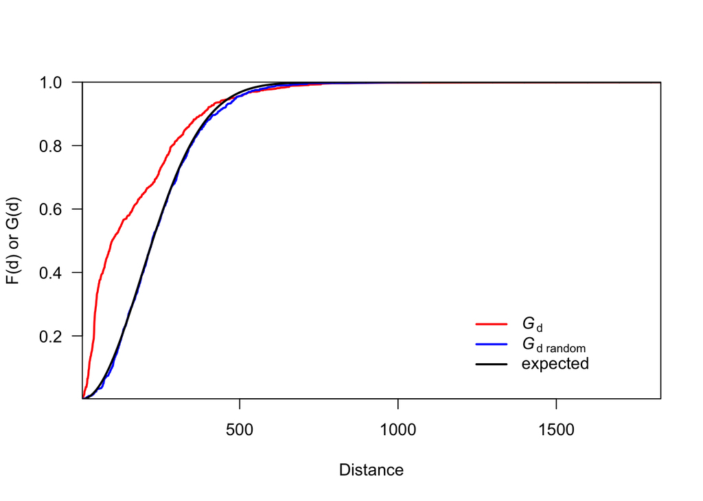

```r
#Set up plot
plot(distance, Gd, type='l', lwd=2, col='red', las=1,
    ylab='F(d) or G(d)', xlab='Distance', yaxs="i", xaxs="i")
#add lines
lines(distance.rnd, Gd.rnd, lwd=2, col='blue')
lines(0:2000, expected, lwd=2)
#add legend
legend(1200, .3,
   c(expression(italic("G")["d"]), expression(italic("G")["d random"]), 'expected'),
   lty=1, col=c('red', 'blue', 'black'), lwd=2, bty="n")
```

## 6 Monte Carlo Siumlation

**(Difficult!) Do a Monte Carlo simulation (page 149) to see if the ‘mean nearest distance’ of the observed crime data is significantly different from a random pattern. Use a ‘for loop’. First write ‘pseudo-code’. That is, say in natural language what should happen. Then try to write R code that implements this.**

Psuedo-code:

- Generate random xy coordinate samples
- calculate the mean nearest dist
- repeat 1000 times
- bind together in dataframe
- create histogram of mean nearest dist
- compare to observed

Function to calculate a random mean nearest distance using the data given above. It gets n number of random observations from the city boundings, then finds the distances, the minimum distance for each point, and calculates the mean:

```r
#` calculates the mean minimum distance for a random generated sample
#` uses the above methods and data to do so
rmean <- function() {
    r <- spsample(city, n=nrow(xy), type = "random") #random sample
    c <- coordinates(r) #get coords
    d <- dist(c) #get distances
    m <- as.matrix(d) #coerce as matrix
    diag(m) <- NA #fill na's for diag
    md <- apply(m, 1, min, na.rm=TRUE) #get min distances
    mdm <- mean(md) #get mean min dist
    return(mdm)
}
```

‘Monte Carlo’ Sampling:

```r
#set random seed
set.seed(20)

#create empty df for use in the loop
mc.test <- data.frame()

#for loop that runs 1000 times for a max p-value of 1/1000
#takes a while, this is running 1000 simulations
for (i in 1:1000) {
  rsamp <- rmean()
  mc.test <- rbind(mc.test, rsamp)
}

#rename the column
colnames(mc.test) <- "rmdist"
```

Observed Mean Minimum Distance:

```r
#get mean min dist of observed dmin
mdmin <- mean(dmin)
```

Visual Exploration:

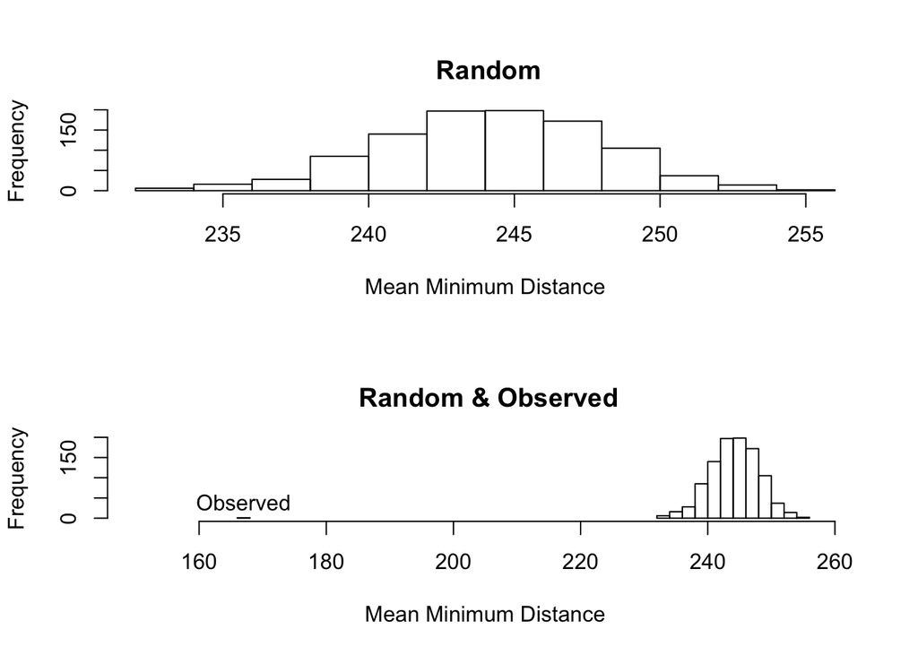

```r
par(mfrow=c(2,1))

#histogram for just the random
hist(mc.test$rmdist, main = "\n Random", xlab = "Mean Minimum Distance")

#get a histogram for the random and observed
hist(mc.test$rmdist, main = "\n Random & Observed", xlab = "Mean Minimum Distance", xlim = c(150, 260))

hist(mdmin, breaks = c(166, 168), labels = "Observed", add = TRUE)
```

> From the second histogram, we can see that the observed value (166.53) falls well outside of the random distribution of mean minimum distances. Given that there are 1000 random observations, the p-value of our observed mean minimum distance would be 1/1000 or 0.001 indicating a significant difference from the random observations.